# PalEON Summer Course: Bayesian statistics module

## August 2016

## Chris Paciorek

In this module, we'll cover the basics of Bayesian statistics, hierarchical modeling, and MCMC.

# The Bayesian recipe: Likelihood, prior and posterior

- **Prior**: \(p(\theta)\) (a pdf or pmf) summarizes our beliefs about \(\theta\) before we collect (or analyze) the dataset we have. \(\theta\) might be a single thing or a vector of things.
- **Posterior**: \(p(\theta|Y_{1}=y_{1},\ldots,Y_{n}=y_{n})\) (a pdf or pmf) summarizes our new beliefs informed by the dataset.
  - Generically, \(p(\theta|y)\) where \(y=\{y_{1},\ldots,y_{n}\}\) indicates the vector of data values.
  - Note that this is a conditional distribution, given the data, which is intuitive.
  - Our goal is to find the posterior mathematically and interpret it scientifically.
- We use Bayes theorem to find \(p(\theta|y)\), making use of \(p(y|\theta)\), by using a version of Bayes theorem for random variables rather than events: \[ p(\theta|Y=y)=\frac{p(y|\theta)p(\theta)}{p(y)}\propto p(y|\theta)p(\theta) \]
- We use the likelihood, \(p(y|\theta)\) (pdf or pmf of the data), to update the prior.

# A basic example with binomial data

We'll illustrate a simple Bayesian analysis using composition data for a single species from a single site. Suppose we are particularly interested in oak composition and we count pollen grains and record the number of oak and number of non-oak grains. We want to know what proportion, \(\theta\), of oak grains there are in the entire 'population', not just the \(n=100\) grains that we counted.

What is the likelihood? I.e., what is the distribution of the data we observe given the unknown of interest?

Ok, now the prior.

**Question**: What could I use as a distribution for the unknown that reflects not having any beliefs in advance of seeing the data? First think about what the possible values of \(\theta\) are.

Ok, once we have a prior and likelihood, we can get an expression proportional to the posterior distribution: \[ p(\theta|y) \propto p(y|\theta)p(\theta) \] \[ \;\;\;\;\;\;\;\;\;\;\;\;\;\;\;\;\;\;\;\;\;\;\; = {n \choose y}\theta^{y}(1-\theta)^{n-y}\cdot1 \] \[ \;\;\;\;\;\;\;\;\;\;\;\; \propto \theta^{y}(1-\theta)^{n-y} \]

So in some sense we are done. We can plot this expression AS A FUNCTION OF \(\theta\), not of \(y\).

Often we want to know the expected value of the posterior distribution, or the variance/standard deviation or percentiles of the distribution.

# The beta distribution

Suppose \(\theta\) is a continuous random variable whose values must be in \((0,1)\). I.e., \(\theta\) could represent a probability.

A distribution that is often used to represent uncertainty in such a random variable is the beta distribution, which has parameters \(\alpha\) and \(\beta\). If a random variable \(\theta\) is distributed according to a beta distribution, its pdf is: \[ f(\theta)=\frac{1}{B(\alpha,\beta)}\theta^{\alpha-1}(1-\theta)^{\beta-1} \]

\(B(\alpha,\beta)\) is a mathematical function that cannot be evaluated in closed form but can be calculated on a computer. Confusingly, it's called the 'beta' function.

The mean and variance of the distribution are: \(E(\theta)=\frac{\alpha}{\alpha+\beta}\); \(Var(\theta)=\frac{\alpha\beta}{(\alpha+\beta)^{2}(\alpha+\beta+1)}\). As we change \(\alpha\) and \(\beta\), we get different beta distributions:

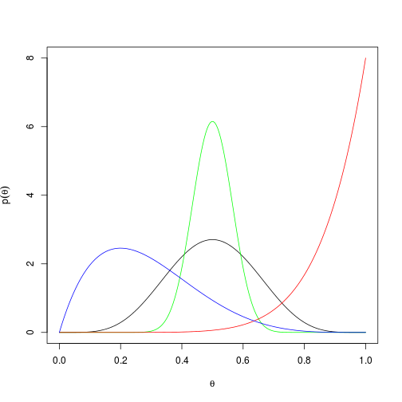

```r
thetas <- seq(0, 1, length = 200)
plot(thetas, dbeta(thetas, 6, 6),
     ylab = expression(p(theta)),
     xlab = expression(theta), type = 'l',
     ylim = c(0, 8))
lines(thetas, dbeta(thetas, 30, 30), col = 'green')
lines(thetas, dbeta(thetas, 8, 1), col = 'red')
lines(thetas, dbeta(thetas, 2, 5), col = 'blue')
```

# Revisiting our example

Recall we have the following: \(p(\theta|y)\propto\theta^{y}(1-\theta)^{n-y}\)

What is the distribution of \(\theta\)?

Suppose \(y=30\) and \(n=100\).

[figure not shown]

```r
y <- 30; n <- 100
thetaSeq <- seq(0, 1, length = 200)
lik <- dbinom(y, n, thetaSeq)
prior <- rep(1, 200)
alphaPost <- y+1; betaPost <- n-y+1
post <- dbeta(thetaSeq, alphaPost, betaPost)
plot(thetaSeq, post, type = 'l')
lines(thetaSeq, prior, col = 'red')
lines(thetaSeq, lik*80, col = 'blue') # scaling of likelihood is arbitrary -- it's not a density for theta
legend(0, 8, legend = c('prior', 'likelihood', 'post'), col = c('red','blue','black'), lty = rep(1,3), bty = 'n')
```

That illustrated prior ignorance. Now suppose we think we know something about this location, and we have some idea about the proportion of oak in the forest. (Perhaps based on a previous study.) For the moment (we'll see why in a minute), let's use a beta distribution to capture our belief about \(\theta\) in advance of seeing the data. Suppose we think there is about 20% oak in the forest with a standard deviation of 10%. We can roughly capture this belief using a beta distribution with \(\alpha=3\), \(\beta=12\).

**Challenge**: How did I come up with \(\alpha\) and \(\beta\)?

Let's go back to likelihood times prior:

\[ p(\theta|y) \propto p(y|\theta)p(\theta) \] \[ = {n \choose y}\theta^{y}(1-\theta)^{n-y}\frac{1}{B(\alpha,\beta)}\theta^{\alpha-1}(1-\theta)^{\beta-1} \] \[ \propto \theta^{y}(1-\theta)^{n-y}\theta^{\alpha-1}(1-\theta)^{\beta-1} \] \[ = \theta^{y+\alpha-1}(1-\theta)^{n-y+\beta-1} \]

**Questions**: What is the posterior distribution of \(\theta\) now? What is the posterior expected value? What is the posterior variance?

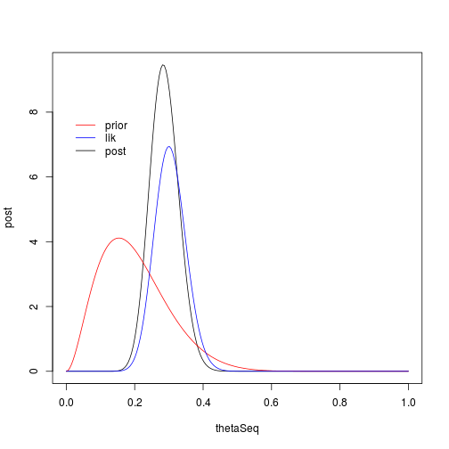

```r
y <- 30; n <- 100
thetaSeq <- seq(0, 1, length = 200)
lik <- dbinom(y, n, thetaSeq)
alphaPrior <- 3; betaPrior <- 12
prior <- dbeta(thetaSeq, alphaPrior, betaPrior)
alphaPost <- y+alphaPrior; betaPost <- n-y+betaPrior
post <- dbeta(thetaSeq, alphaPost, betaPost)
plot(thetaSeq, post, type = 'l')
lines(thetaSeq, prior, col = 'red')
lines(thetaSeq, lik*80, col = 'blue')  # scaling arbitrary
legend(0, 8, legend = c('prior', 'lik', 'post'), col = c('red','blue','black'), lty = rep(1,3), bty = 'n')
```

# Using the posterior distribution

If we know the posterior as an actual distribution, we can use the posterior mean (or median) as our estimate and get a 95% uncertainty (credible) interval from the 2.5th and 97.5th percentiles of the distribution.

```r
y <- 30; n <- 100
alphaPost <- y+1; betaPost <- n-y+1
qbeta(c(.025, .5, .975), alphaPost, betaPost)
```

```
## [1] 0.2189787 0.3026356 0.3961471
```

```r
postMean <- alphaPost/(alphaPost + betaPost)
postSD <- sqrt(alphaPost*betaPost / ((alphaPost + betaPost)^2 * (alphaPost
 + betaPost + 1)))
postMean
```

```
## [1] 0.3039216
```

```r
postSD
```

```
## [1] 0.04532014
```

Often we won't know the distribution as a standard distribution but we will have a sample from the distribution. In particular we'll often have output from an MCMC. Recall from the statistics module that we can use empirical quantities calculated from a sample from a distribution to approximate the characteristics of the distribution.

```r
####### PAY NO ATTENTION TO THE MAN BEHIND THE CURTAIN ######
fakeMCMCsample <- rbeta(2000, alphaPost, betaPost)
#############################################################

# now use 'fakeMCMCsample' as if it came from an actual MCMC,
# ignoring the fact that theta has a beta distribution

quantile(fakeMCMCsample, c(.025, .5, .975))
```

```
##      2.5%       50%     97.5%
## 0.2163316 0.3028659 0.3967816
```

```r
mean(fakeMCMCsample)
```

```
## [1] 0.303982
```

```r
sd(fakeMCMCsample)
```

```
## [1] 0.04641211
```

# Hierarchical models and latent processes

The basic idea of a hierarchical model is to create a mathematical representation (a model) using the language of probability distributions to capture the main features of our data and the underlying process of interest. Our goal is generally to either better understand features of the underlying process or make predictions based on the model.

## A basic hierarchical model

The most basic hierarchical model has a data layer, a single latent layer, and a layer of (hyper)parameters. Let's suppose we have data on rats in a laboratory (say some metabolite in blood), with each mother rat having multiple pups, and with us measuring the metabolite outcome on each pup. We want a model that accounts for the fact that pups within a litter are related. Option A would be to try to introduce some sort of correlation structure into how we model the data. But let's first consider an alternative, Option B, that adds some variables to help guide our thinking about the process at hand.

\[ y_{im} \sim \mathcal{N}(\mu_{m},\sigma^{2});\, i=1,\ldots,n_{m} \] \[ \mu_{m} \sim \mathcal{N}(\theta,\tau^{2})\, m=1,\ldots,M \]

On the board, we'll consider a graphical representation of this model. (In the BUGS manuals and examples, you'll see lots of model structures illustrated as graphs.)

Now let's return to Option A. In a model with latent values such as this one, a basic statistical approach to dealing with the high dimensionality is to integrate over the latent values. If we do this (integrating over \(\mu=(\mu_{1},\ldots,\mu_{M})\), we end up with a model that I'll illustrate on the board, with a so-called compound symmetry correlation structure.

So far there hasn't really been a scientific question; we've just tried to model the structure of the data. Let's take the analogue of a simple t-test. Assume we have two groups of mothers and we test a drug or a chemical in one group and use the other group as the placebo.

**Challenge**: How would we change our initial model and what quantity in the model is now the main focus of interest? What would a graph of the model look like?

Now let's talk through what would be needed to modify this model to relate to vegetation data. Let's consider stands of trees within a forest. Question: What aspects of the model would change?

Note: henceforth I'll refer to all the unknowns (latent process values and hyperparameters) as the 'parameters'. Basically anything that is not data or fixed constants (such as sample sizes and covariates/predictors) is a parameter in the model.

## Prediction

Let's think about how we would make predictions from this model. Suppose I either know all the unknown parameters and latent values or have estimates for them.

**Questions**:

1. What is our best guess for the \(y\) for a new pup from the first mother?
2. What is our best guess for the \(\mu\) for a mother for whom we have no data?
3. What is our best guess for the \(y\) for a new pup from a mother for which we don't have data?
4. Comparing #1 and #3, for which one should our uncertainty be greater? Let's consider \(\mbox{Var}(y|\mu)\) and \(\mbox{Var}(y|\theta)\), but first let's consider questions 5-7.
5. How can I draw a sample of possible \(y\)'s for a new pup from the first mother?
6. How can I draw a sample of possible \(y\)'s for a new pup from a mother with no data?
7. How does our construction of new \(y\)'s support our conclusion in #4?

The distribution of new data is called the *predictive distribution*.

## Adding complexity to the latent layer

Let's consider a model for the evolution of sediment pollen over time. Unlike the above example, we want the latent values to be related to each other in a manner informed by the time structure.

One common model in these contexts, if we treat time as being discrete, is a hidden Markov model (HMM), also known as a dynamic linear model (DLM) and as a state space model.

\[ y_{t} \sim \mathcal{N}(\theta_{t},\sigma^{2}) \] \[ \theta_{t} \sim \mathcal{N}(\mu + \rho(\theta_{t-1}-\mu),\tau^{2}) \]

The first equation is the likelihood, or the noise model. The second equation is the model for the latent (or hidden) process, which may be called the state model or the latent process. It's a 'hidden' model because we don't directly observe the process. It's a Markov model because the latent process value at time \(t\) depends only on the process value at the previous time step.

To complete the Bayesian model, we need prior distributions for the parameters and for the initial state, \(p(\mu, \rho, \sigma^{2},\tau^{2},\theta_{0})\).

For the statistics module, you wrote code in R to simulate from a simplified version of this model. That 'forward' simulation took the parameters as known and simulated data that might be generated from such a model. Our Bayesian analysis in the simple binomial model for oak pollen above did the reverse: it took the data and a model structure and tried to reconstruct what the plausible values of the unknown parameters and latent values are. Thus our Bayesian statistical analysis is also known as an 'inverse' problem.

## General DLMs

More generally, we might have data and process values that relate to each other in more complicated ways. For example, we might have the following where \(y_{t}\) and \(\theta_{t}\) are vectors at each time step: \[ y_{t} \sim \mathcal{N}(H_{t}\theta_{t},R_{t}) \] \[ \theta_{t} \sim \mathcal{N}(F_{t}\theta_{t-1},\Sigma_{t}) \]

This set of equations relates to an algorithm known as the Kalman filter, which is a way to estimate \(\theta_{t}\) given data \(y_{t}\) and an estimate of the previous state, \(\hat{\theta}_{t-1}\). One way to think about the Kalman filter is that it is just as a hierarchical model where we use probability manipulations to estimate \(\theta_{t}\) over time and to make predictions into the future.

And of course the distributions might not be normal. In that case one gets into more advanced variants on the Kalman filter.

# Our first MCMC

Markov chain Monte Carlo is a computational technique used to simulate a sample from a posterior distribution. There are a variety of MCMC approaches.

One basic strategy is called Gibbs sampling - it involves cycling through the parameters and sampling from

\[ p(\theta_{1}|\theta_{2},\ldots,\theta_{p},y) \] \[ p(\theta_{2}|\theta_{1},\theta_{3},\ldots,\theta_{p},y) \] \[ \cdots \] \[ p(\theta_{p}|\theta_{1},\ldots,\theta_{p-1},y) \]

In this case, \(\theta\) would include ALL of the unknown parameters, both latent process values and hyperparameters.

Let's see an example of this. We'll use a bivariate normal distribution to illustrate things. Let's assume that we 'forget' that we know how to simulate directly from a bivariate normal.

Suppose we've done the math to figure out that

\[ \theta_{1}|\theta_{2},y \sim \mathcal{N}\left(\mu_{1}+\sigma_{1}\rho\frac{\theta_{2}-\mu_{2}}{\sigma_{2}},\sigma_{1}^{2}(1-\rho^{2})\right) \] \[ \theta_{2}|\theta_{1},y \sim \mathcal{N}\left(\mu_{2}+\sigma_{2}\rho\frac{\theta_{1}-\mu_{1}}{\sigma_{1}},\sigma_{2}^{2}(1-\rho^{2})\right) \]

where \(\mu_{1}=0\), \(\mu_{2}=1\), \(\sigma_{1}=\sigma_{2}=1\), \(\rho=0.7\) are functions of \(y\). This example is particularly useful because in many models, the posterior distribution of \(\theta\) is approximately multivariate normal distributed.

So let's set up a Gibbs sampler to draw samples from \(p(\theta_{1},\theta_{2}|y)\)

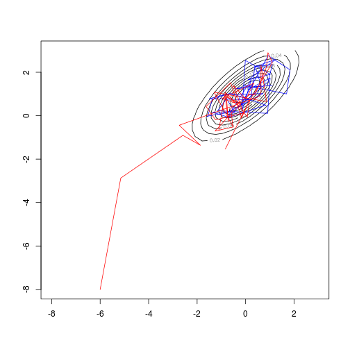

```r
nIts <- 1000
nPlot <- 40
mu1 <- 0; mu2 <- 1; sig1 <- 1; sig2 <- 1; rho <- .7
store <- matrix(NA, nrow = nIts, ncol = 2)
luckyStartingValues <- c(.1, 1.2)
store[1, ] <- luckyStartingValues
for(it in 2:nIts){
    curTheta2 <- store[it-1, 2]
    curTheta1 <- rnorm(1, mu1 + sig1*rho*(curTheta2 - mu2)/sig2, sig1*sqrt(1-rho^2))
    curTheta2 <- rnorm(1, mu2 + sig2*rho*(curTheta1 - mu1)/sig1, sig2*sqrt(1-rho^2))
    store[it, ] <- c(curTheta1, curTheta2)
}

# we know the 'true' 'posterior', so let's plot its contours to see how well we are doing
library(mvtnorm, quietly = TRUE)
gridLength <- 40
grid1d <- seq(-8, 3, length = gridLength)
grid2d <- expand.grid(grid1d, grid1d)
densValues <- dmvnorm(grid2d, c(mu1, mu2), matrix(c(sig1^2, rho*sig1*sig2, rho*sig1*sig2, sig2^2), 2, 2))
contour(grid1d, grid1d, matrix(densValues, gridLength))
lines(store[1:nPlot, 1], store[1:nPlot, 2], col = 'blue')

store2 <- matrix(NA, nrow = nIts, ncol = 2)
unluckyStartingValues <- c(-6, -8)
store2[1, ] <- unluckyStartingValues
for(it in 2:nIts){
    curTheta2 <- store2[it-1, 2]
    curTheta1 <- rnorm(1, mu1 + sig1*rho*(curTheta2 - mu2)/sig2, sig1*sqrt(1-rho^2))
    curTheta2 <- rnorm(1, mu2 + sig2*rho*(curTheta1 - mu1)/sig1, sig2*sqrt(1-rho^2))
    store2[it, ] <- c(curTheta1, curTheta2)
}
lines(store2[1:nPlot, 1], store2[1:nPlot, 2], col = 'red')
```

Often when we want to use this sequential updating strategy, the conditional distribution of a parameter is not a known distribution from which we can easily sample. In such cases, we often use Metropolis (or Metropolis-Hastings) sampling. Other techniques such as slice sampling or adaptive rejection sampling are also used. We won't go into these, but they are used 'under the hood' in JAGS and other software.

# Convergence and mixing of MCMC chains

MCMC chains can suffer from two major problems:

- The chain takes a long time to converge (bad starting values).
- The chain has converged but is mixing slowly (the samples are highly dependent).

We can take a look at these issues using 'trace plots' of the MCMC output.

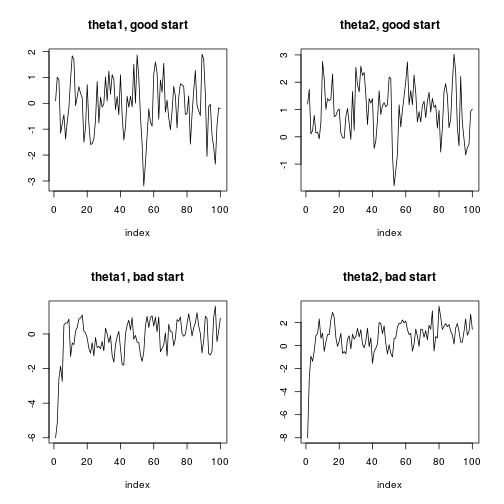

```r
par(mfrow = c(2,2))
subset <- 1:100
tsplot <- function(vec, ...){
    plot(1:length(vec), vec, xlab = 'index', ylab = '', ...)
}

tsplot(store[subset, 1], main = 'theta1, good start', type = 'l')
tsplot(store[subset, 2], main = 'theta2, good start', type = 'l')
tsplot(store2[subset, 1], main = 'theta1, bad start', type = 'l')
tsplot(store2[subset, 2], main = 'theta2, bad start', type = 'l')
```

To deal with the (1) the convergence issues, we throw out the initial part of the chain and don't use it to make our estimates. In this case we only have to throw out a few values even with the bad starting values, but in many situations, we need to throw out thousands of samples. (2) Mixing is a problem because we have fewer effectively-independent samples. Recall our discussion in the statistics module that if we have a large sample from a distribution, that sample is a good representation of the distribution. If we have a small sample, it may not be. When we have highly-correlated samples we don't have as good a representation as when the samples are independent.

Two of the main causes of convergence and mixing problems are bad starting values and high correlation between parameters. There are strategies for 'blocking' parameters that try to allow the parameters to explore the parameter space in a way that respects the correlation. I'll illustrate this on the board.

# Using the output of MCMC chains

The basic story here is that the chain output is a sample from the posterior (provided we've thrown away values from the burn-in period). We can use the sample to approximate the posterior mean, posterior sd, and posterior quantiles.

```r
library(coda, quietly = TRUE) # a package for manipulating MCMC output
nonBurn <- 100:nIts  # conservative in this case
use <- store[nonBurn, ]
ess1 <- effectiveSize(use[, 1])
ess2 <- effectiveSize(use[, 2])
postMean <- colMeans(use)
postSD <- apply(use, 2, sd)
uncIntervals <- apply(use, 2, quantile, c(.025, .975))
postCorr <- cor(use[, 1], use[ , 2])
postMean; postSD; uncIntervals; postCorr
```

```
## [1] 0.005806095 0.999656480
```

```
## [1] 1.019561 1.004351
```

```
##            [,1]      [,2]
## 2.5%  -2.017634 -1.062005
## 97.5%  1.959981  2.914559
```

```
## [1] 0.7064049
```

Apart from our posterior correlation estimate, the other quantities we calculated represent the marginal posteriors: \(p(\theta_{1}|y)\) and \(p(\theta_{2}|y)\). In this context we can just ignore the samples of the parameters we are not interested in. We're generally not interested in conditional posteriors such as \(p(\theta_{1}|\theta_{2},y)\), but if we were, we could have just fixed \(\theta_{2}\) at the value we want to condition on.

MCMC output provides a huge amount of flexibility. If I am interested in some function of \(\theta\), I can just find the function of each of the samples, and that gives me a sample of the function. Suppose \(\theta_{1}\) was on the log scale and I want it on the original scale.

```r
derivedQuant <- exp(use[ , 1])
postMeanDerived <- mean(derivedQuant)
postCIsDerived <- quantile(derivedQuant, c(.025, .975))
postMeanDerived; postCIsDerived
```

```
## [1] 1.696482
```

```
##      2.5%     97.5%
## 0.1329794 7.0992061
```